# Chiara weekend homework week 6

# MPV

## 1.1 Hypothesis testing - practical

```r
library(tidyverse)
library(janitor)
library(infer)
data(msleep)
```

### Question 1:

Explore the dataset and familiarise yourself with it.

```r
msleep <- msleep
head(msleep)
```

| name | genus | vore | order | conservation | sleep_total | sleep_rem | sleep_cycle | awake | brainwt | bodywt |
| --- | --- | --- | --- | --- | --- | --- | --- | --- | --- | --- |
| Cheetah | Acinonyx | carni | Carnivora | lc | 12.1 | NA | NA | 11.9 | NA | 50.000 |
| Owl monkey | Aotus | omni | Primates | NA | 17.0 | 1.8 | NA | 7.0 | 0.01550 | 0.480 |
| Mountain beaver | Aplodontia | herbi | Rodentia | nt | 14.4 | 2.4 | NA | 9.6 | NA | 1.350 |
| Greater short-tailed shrew | Blarina | omni | Soricomorpha | lc | 14.9 | 2.3 | 0.1333333 | 9.1 | 0.00029 | 0.019 |
| Cow | Bos | herbi | Artiodactyla | domesticated | 4.0 | 0.7 | 0.6666667 | 20.0 | 0.42300 | 600.000 |
| Three-toed sloth | Bradypus | herbi | Pilosa | NA | 14.4 | 2.2 | 0.7666667 | 9.6 | NA | 3.850 |

```r
glimpse(msleep)
```

```
Rows: 83
Columns: 11
$ name         <chr> "Cheetah", "Owl monkey", "Mountain beaver", "Greater short-tailed shrew", "Cow", "Three-toed sloth", "Norther…
$ genus        <chr> "Acinonyx", "Aotus", "Aplodontia", "Blarina", "Bos", "Bradypus", "Callorhinus", "Calomys", "Canis", "Capreolu…
$ vore         <chr> "carni", "omni", "herbi", "omni", "herbi", "herbi", "carni", NA, "carni", "herbi", "herbi", "herbi", "omni", …
$ order        <chr> "Carnivora", "Primates", "Rodentia", "Soricomorpha", "Artiodactyla", "Pilosa", "Carnivora", "Rodentia", "Carn…
$ conservation <chr> "lc", NA, "nt", "lc", "domesticated", NA, "vu", NA, "domesticated", "lc", "lc", "domesticated", "lc", "domest…
$ sleep_total  <dbl> 12.1, 17.0, 14.4, 14.9, 4.0, 14.4, 8.7, 7.0, 10.1, 3.0, 5.3, 9.4, 10.0, 12.5, 10.3, 8.3, 9.1, 17.4, 5.3, 18.0…
$ sleep_rem    <dbl> NA, 1.8, 2.4, 2.3, 0.7, 2.2, 1.4, NA, 2.9, NA, 0.6, 0.8, 0.7, 1.5, 2.2, 2.0, 1.4, 3.1, 0.5, 4.9, NA, 3.9, 0.6…
$ sleep_cycle  <dbl> NA, NA, NA, 0.1333333, 0.6666667, 0.7666667, 0.3833333, NA, 0.3333333, NA, NA, 0.2166667, NA, 0.1166667, NA, …
$ awake        <dbl> 11.90, 7.00, 9.60, 9.10, 20.00, 9.60, 15.30, 17.00, 13.90, 21.00, 18.70, 14.60, 14.00, 11.50, 13.70, 15.70, 1…
$ brainwt      <dbl> NA, 0.01550, NA, 0.00029, 0.42300, NA, NA, NA, 0.07000, 0.09820, 0.11500, 0.00550, NA, 0.00640, 0.00100, 0.00…
$ bodywt       <dbl> 50.000, 0.480, 1.350, 0.019, 600.000, 3.850, 20.490, 0.045, 14.000, 14.800, 33.500, 0.728, 4.750, 0.420, 0.06…
```

### Question 2:

Jabberwockies sleep for around 7 hours a night, on average. Perform an appropriate statistical test to determine whether the mean sleep_total in the sampled population of animal types differs from the typical value for jabberwockies.

We start calculating the observed statistic that represent the total slepp hours of the animal in the dataset

```r
observed_stat <- msleep %>%
  summarise(mean_sleep = mean(sleep_total, na.rm = TRUE))

observed_stat
```

| mean_sleep |
| --- |
| 10.43373 |

We then set the hypothesis.

*H0:* The mean of the total sleep hours of the dataset is = 7 *H1:* The mean of the total sleep hours of the dataset is != 7

We set *alpha* = 0.05

We calculate the null distribution

```r
null_dist <- msleep %>%
  specify(response = sleep_total) %>%
  hypothesise(null = "point", mu = 7) %>%
  generate(reps = 5000, type = "bootstrap") %>%
  calculate(stat = "mean")
```

```r
observed_stat <- msleep %>%
  specify(response = sleep_total) %>%
  calculate(stat = "mean")

observed_stat
```

```
Response: sleep_total (numeric)
```

| stat |
| --- |
| 10.43373 |

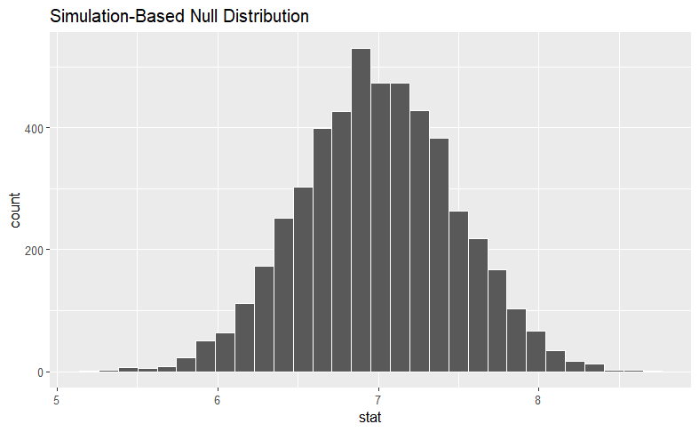

```r
null_dist %>%
  visualise(bins = 30)
```

```r
null_dist %>%
  visualise(bins = 30) +
  shade_p_value(obs_stat = observed_stat$mean_sleep, direction = "both")
```

```
Avvertimento: Unknown or uninitialised column: `mean_sleep`.
```

```
list()
```

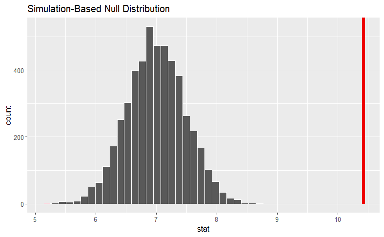

```r
null_dist %>%
  visualise(bins = 30) +
  shade_p_value(obs_stat = observed_stat, direction = "both")
```

```r
p_value <- null_dist %>%
  get_p_value(obs_stat = observed_stat, direction = "both")
```

```
Avvertimento: Please be cautious in reporting a p-value of 0. This result is an approximation based on the number of `reps` chosen in the `generate()` step. See `?get_p_value()` for more information.
```

```r
p_value
```

| p_value |
| --- |
| 0 |

```r
p_value <- null_dist %>%
  get_p_value(obs_stat = observed_stat$mean_sleep, direction = "both")
```

[output not shown]